# R Basics

Author

Marcio A Diniz, PhD

Published

September 8, 2022

# Introduction

## First steps in R

[figure not shown]

Coding in R is like playing with Lego

R is an object-oriented language. Objects can be interpreted as boxes that we can use to store different classes of content. These objects always have a name that can be interpreted a label for boxes. Object names or labels should always start with letters and it also can contain numbers, but only a few special characters: underscore or period.

## Types of objects

[figure not shown]

There are different types of objects

Objects in R can be classified in three classes of content: - Numeric objects contain numbers such that they can be double (dbl) or integers (int); - Character (chr) objects contain strings, i.e., text between quotes; - If a character object contains only a pre-defined set of values, then it is considered a factor (fct). - Logical objects (lgl) contain logical statements, i.e., TRUE or FALSE.

Let’s code our first objects. In order to store content to an object, we use the assignment operator <- or =.

```r
# Who is it?
dwo_icecream <- 11 # days without icecream
favorite_food <- "risotto"
dog.lover = TRUE
enjoy_cold <- FALSE
```

Objects can be accessed based on their names:

```r
dwo_icecream
```

```
[1] 11
```

```r
favorite_food
```

```
[1] "risotto"
```

```r
enjoy_cold
```

```
[1] FALSE
```

We can see these objects are listed in the Environment tab.

## Good practices for coding in R

[figure not shown]

Describe and comment your code for your future self!

[figure not shown]

Describe and comment your code for your colleagues!

Good practices for coding in R suggest to avoid . on names of objects and = as assignment operator. Therefore, we can rename one of the objects we have just created to follow this convention:

```r
dog_lover <- dog.lover
```

Now, the function rm removes objects from the **Environment** tab.

```r
rm(dog.lover)
dog_lover
```

```
[1] TRUE
```

## Vectors

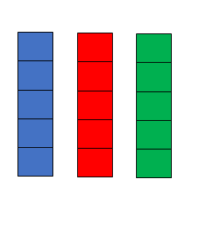

Vectors

Vectors are stacked objects with different lengths, but the same type of objects.

We can combine objects using the function c.

```r
dwo_icecream <- c(5, 10, 8, 9, 3) # days without ice-cream
dwo_icecream
```

```
[1]  5 10  8  9  3
```

```r
pushups <- c(1, 10, 0, 30, 25)
pushups
```

```
[1]  1 10  0 30 25
```

We can also calculate the length of a vector using the function length.

```r
length(dwo_icecream)
```

```
[1] 5
```

All previous objects are also vectors, but with length 1:

```r
length(favorite_food)
```

```
[1] 1
```

If we combine different types of vectors, they will be converted following the hierarchy: character > numeric > logical:

```r
# coerced all objects as characters
c(favorite_food, dog_lover, enjoy_cold, dwo_icecream)
```

```
[1] "risotto" "TRUE"    "FALSE"   "5"       "10"      "8"       "9"
[8] "3"
```

```r
c(dog_lover, dwo_icecream)  # TRUE is converted into 1
```

```
[1]  1  5 10  8  9  3
```

```r
c(enjoy_cold, dwo_icecream)  # FALSE is converted into 0
```

```
[1]  0  5 10  8  9  3
```

We can check the class of objects using the function class.

```r
class(dwo_icecream)
```

```
[1] "numeric"
```

```r
class(dog_lover)
```

```
[1] "logical"
```

```r
class(favorite_food)
```

```
[1] "character"
```

Some numeric vectors can also be created with easier approaches than use the function c:

- Using the function rep:

```r
x <- c(1, 1, 1, 1, 1)
x
```

```
[1] 1 1 1 1 1
```

```r
y <- rep(1, 5)
y
```

```
[1] 1 1 1 1 1
```

- Using the function seq:

```r
x <- c(1, 2, 3, 4, 5)
x
```

```
[1] 1 2 3 4 5
```

```r
y <- 1:5
y
```

```
[1] 1 2 3 4 5
```

```r
z <- seq(1, 5, by = 1)
z
```

```
[1] 1 2 3 4 5
```

## Factors

Factors are special vectors that assume only pre-defined values defined using function factor:

- It can be created based on a character vector:

```r
dog_lover <- c("yes", "no", "yes", "yes", "yes")
dog_lover <- factor(dog_lover,
                    levels = c("no", "yes"))
dog_lover
```

```
[1] yes no  yes yes yes
Levels: no yes
```

- Or a numeric vector:

```r
dog_lover <- c(1, 0, 1, 1, 1)
dog_lover <- factor(dog_lover,
                    levels = c(0, 1),
                    labels = c("no", "yes"))
dog_lover
```

```
[1] yes no  yes yes yes
Levels: no yes
```

We can use easily transform a character vector into a factor.

```r
dog_lover <- c("yes", "no", "yes", "yes", "yes")
dog_lover <- as.factor(dog_lover)
dog_lover
```

```
[1] yes no  yes yes yes
Levels: no yes
```

It is important to notice that factors have ordered levels:

```r
dog_lover
```

```
[1] yes no  yes yes yes
Levels: no yes
```

```r
levels(dog_lover)
```

```
[1] "no"  "yes"
```

```r
nlevels(dog_lover)
```

```
[1] 2
```

## Matrices

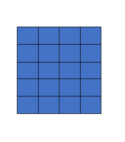

a matrix

- Matrix is a collection of vectors of the same type and length organized in a two-dimensional array;
- A matrix has n rows and p columns.
- Vectors can be bounded into two-dimensional arrays using the function cbind:

```r
m <- cbind(dwo_icecream, pushups)
m
```

```
     dwo_icecream pushups
[1,]            5       1
[2,]           10      10
[3,]            8       0
[4,]            9      30
[5,]            3      25
```

- The class of two-dimensional arrays generated by cbind is matrix:

```r
class(m)
```

```
[1] "matrix" "array"
```

```r
names <- c("m", "n", "p", "b", "t")
m <- cbind(names, dog_lover,
           dwo_icecream, pushups)
```

```r
m
```

```
     names dog_lover dwo_icecream pushups
[1,] "m"   "2"       "5"          "1"
[2,] "n"   "1"       "10"         "10"
[3,] "p"   "2"       "8"          "0"
[4,] "b"   "2"       "9"          "30"
[5,] "t"   "2"       "3"          "25"
```

- Matrices are not appropriate to store a dataset.

## Data frames

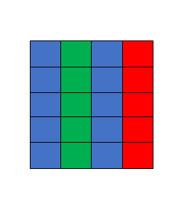

a data frame

- A data frame is a collection of vectors of the same/different types but of the same length organized in a two-dimensional array;
- A data frame has n rows and p columns.
- Data frames are created with the function data.frame:

```r
df <- data.frame(names, dog_lover,
                 dwo_icecream, pushups)
df
```

```
  names dog_lover dwo_icecream pushups
1     m       yes            5       1
2     n        no           10      10
3     p       yes            8       0
4     b       yes            9      30
5     t       yes            3      25
```

```r
class(df)
```

```
[1] "data.frame"
```

# Subsetting

## Vectors

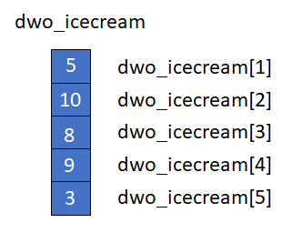

positions of a vector

Subsetting a vector allows us to access each component of the vector. Components of a vector can be accessed using the operator [position].

```r
dwo_icecream
```

```
[1]  5 10  8  9  3
```

```r
dwo_icecream[1]
```

```
[1] 5
```

```r
dwo_icecream[c(1, 5)]
```

```
[1] 5 3
```

## Matrices

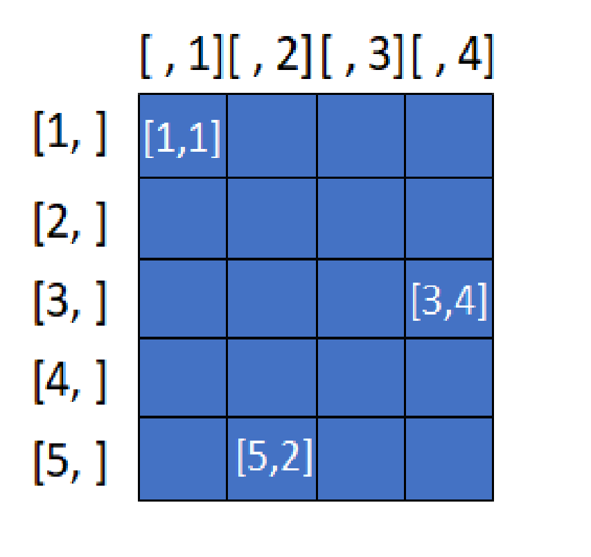

positions of a matrix

Subsseting a matrix is quite similar to subset vector, except that the position of a component of a matrix is two-dimensional: [position row, position column].

We can access a specific component, a row and a column in a matrix:

```r
# a specific component
m[1, 1]
```

```
names
  "m"
```

```r
# a row
m[5, ]
```

```
       names    dog_lover dwo_icecream      pushups
         "t"          "2"          "3"         "25"
```

```r
# a column
m[, 4]
```

```
[1] "1"  "10" "0"  "30" "25"
```

## Data frames

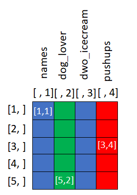

positions of a data frame

Subsetting a data frame follows the same idea of subsetting a matrix. In addition, columns can be accessed be their names using the operator $.

We can access a specific component, a row and a column in a data frame:

```r
df$names[5]
```

```
[1] "t"
```

```r
df[5, 1]
```

```
[1] "t"
```

```r
df$names
```

```
[1] "m" "n" "p" "b" "t"
```

```r
df[, 1]
```

```
[1] "m" "n" "p" "b" "t"
```

```r
df[5, ]
```

```
  names dog_lover dwo_icecream pushups
5     t       yes            3      25
```

# Logical statements

## Object classes

Logical statements can help us to check the class of objects:

```r
is.numeric(dwo_icecream)
```

```
[1] TRUE
```

```r
is.logical(dwo_icecream)
```

```
[1] FALSE
```

```r
is.character(dwo_icecream)
```

```
[1] FALSE
```

```r
is.factor(dog_lover)
```

```
[1] TRUE
```

We can check conditions regarding the content of objects:

- Are these objects equal?

```r
dog_lover == "yes"
```

```
[1]  TRUE FALSE  TRUE  TRUE  TRUE
```

- Are these objects different?

```r
dog_lover != "yes"
```

```
[1] FALSE  TRUE FALSE FALSE FALSE
```

```r
dwo_icecream > 7 # for less, use <
```

```
[1] FALSE  TRUE  TRUE  TRUE FALSE
```

```r
dwo_icecream >= 7 # for less or equal, use <=
```

```
[1] FALSE  TRUE  TRUE  TRUE FALSE
```

Moreover, we can combine these conditions producing complex logical statements:

- AND

```r
dwo_icecream > 7 & dog_lover == "yes"
```

```
[1] FALSE FALSE  TRUE  TRUE FALSE
```

- OR

```r
dwo_icecream > 7 | dog_lover == "no"
```

```
[1] FALSE  TRUE  TRUE  TRUE FALSE
```

# Functions

## What is a function?

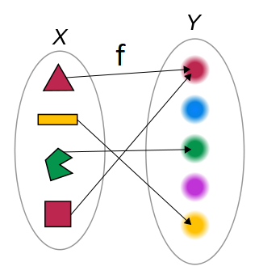

The function f takes objects from in X and transform them into objects in Y

A function takes inputs, make operations and gives back outputs. Functions in R are organized in libraries. Every function has a documentation that can be accessed with the operator ?.

First, we can access the documentation of some of these functions:

```r
?length
```

```
starting httpd help server ... done
```

```r
?c
```

In the tab **Help**, we can find more details of the function, including examples.

## Creating our own function

We can create our own functions. For example, we can create a function to convert temperature in Fahrenheit to Celsius.

How would we do this conversion manually?

```r
# minimum temperature
temp_f <- 38
temp_c <- (temp_f - 32)*(5/9)
temp_c
```

```
[1] 3.333333
```

```r
# range of temperatures
temp_f <- c(38, 105)
temp_c <- (temp_f - 32)*(5/9)
temp_c
```

```
[1]  3.333333 40.555556
```

How about with a function?

```r
temp_f_c <- function(temp_f){

  temp_c <- (temp_f - 32)*(5/9)

  return(temp_c)
}

temp_f_c(38)
```

```
[1] 3.333333
```

```r
temp_f_c(105)
```

```
[1] 40.55556
```

```r
temp_f_c(c(38, 105))
```

```
[1]  3.333333 40.555556
```

# For loops

How can we repeat tasks or perform them sequentially?

```r
i <- 1
i
```

```
[1] 1
```

```r
i <- i + 1
i
```

```
[1] 2
```

```r
i <- i + 1
i
```

```
[1] 3
```

A for loop replaces repeated code:

```r
for (i in 1:3){
  print(i)
}
```

```
[1] 1
[1] 2
[1] 3
```

such that we can use for loops to control the flow of other objects:

```r
x <- rep(NA, 3)

for (i in 1:3){
  x[i] <- i
}
x
```

```
[1] 1 2 3
```